# Smoker’s health exploratory data analysis

Upuli Karunarathna

### **Introduction**

This data set provides the health conditions of both smokers and non smokers. The discription of the data set is as follows.  
Age: Age of a representative in years  
Sex: Gender of a representative (male, female)  
current_smoker: Whether the representative is smoking or not (yes, no)  
heart_rate: Heart rate of a representative  
blood_pressure: Heart rate of a representative (systolic blood pressure/diastolic blood pressure)  
cigs_per_day: Number of cigarettes consumed per day  
chol: cholesterol level of a representative

##### **Checking the outliers**

**1. For age**

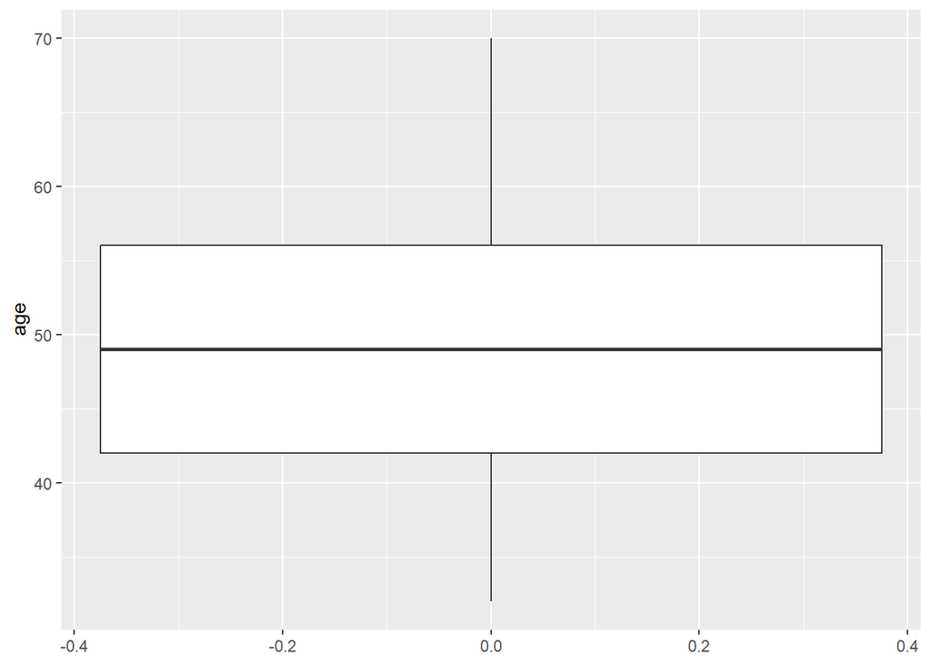

```
integer(0)
```

**2. For heart rate**

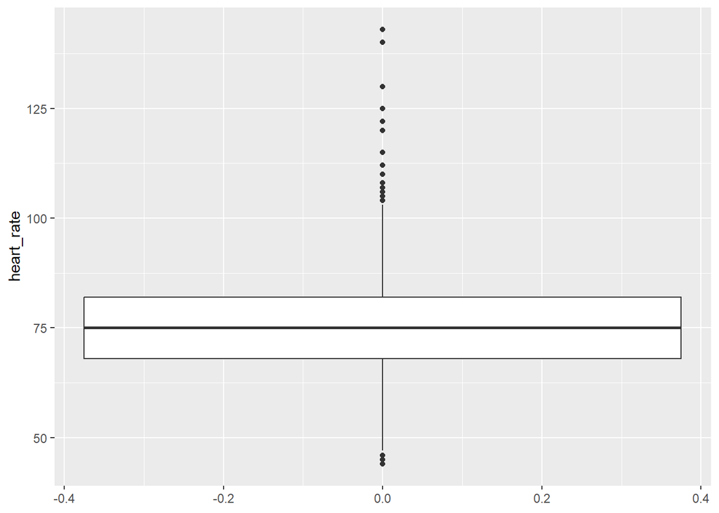

```
 [1] 105 104 120 122 110 107 120 110 106 110 125 110 107 120 115 105 110 115  44
[20] 125  45 140 108 105 110 120 110 143 110 107 110 108 110 106 110 115 125 110
[39] 105 108 110 107 108 105 122 110 110 110 110 110 110  46 105 104 105 105 120
[58] 110 105 110 105  45 110 110 120 110 112 120 108 112 105 110 105 130 104 108
[77] 110 110 110 115 115 110 110 110 110
```

Even though the box plot represents outliers, considering real scenarios these can not be eliminated.

**3. For systolic blood pressure**

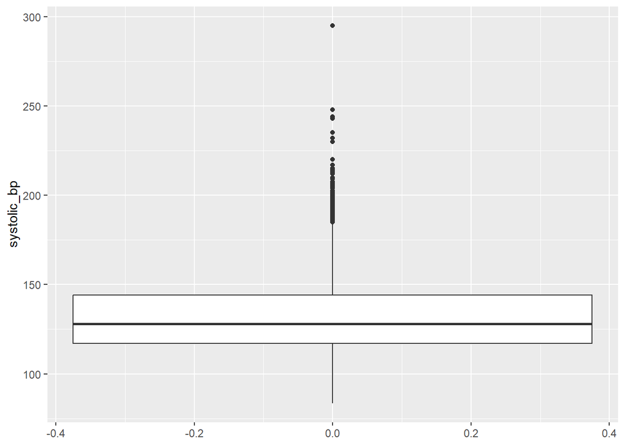

```
  [1] 197.0 187.0 190.0 206.0 220.0 204.0 235.0 190.0 212.0 206.0 193.0 198.0
 [13] 206.0 196.0 210.0 244.0 232.0 205.5 191.0 202.5 201.0 186.5 190.0 191.0
 [25] 186.0 196.0 197.5 215.0 195.0 192.5 189.0 200.0 190.0 248.0 190.0 187.5
 [37] 185.5 185.0 193.0 195.0 204.0 214.0 206.0 192.0 196.0 191.0 189.0 195.0
 [49] 188.0 199.0 204.0 202.0 200.0 213.0 188.5 207.0 209.0 213.0 199.0 197.0
 [61] 193.0 185.0 187.0 190.0 186.5 199.5 189.0 194.0 192.5 196.0 243.0 185.0
 [73] 185.5 210.0 295.0 210.0 200.0 197.0 197.5 205.0 185.0 197.0 202.0 189.0
 [85] 186.0 189.0 187.0 185.0 195.0 191.0 198.0 195.0 230.0 217.0 200.0 188.0
 [97] 215.0 187.0 192.0 193.0 196.0 210.0 215.0 220.0 200.0 189.0 198.0 192.5
[109] 196.0 190.0 199.0 207.5
```

- Ditermining the value of extreme outlier

```
[1] 295
```

##### Since there is an extreme outlier compared to other outliers and when considering the general case also there is a rare chance of having such value.Therefore it is remved from the data set.

**4. For diastolic blood pressure**

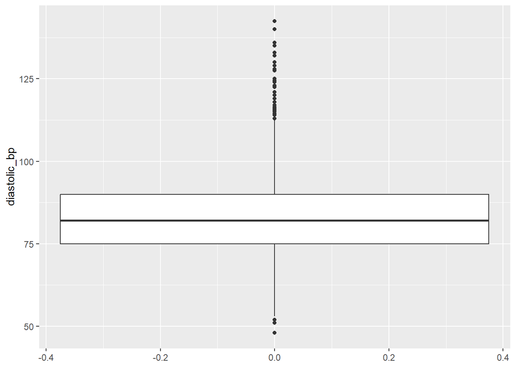

```
 [1]  52.0  52.0 116.0 120.0 120.0 120.0 120.0 124.0 136.0 116.5 124.5 113.0
[13] 113.0 113.0 117.0 121.0 121.0 125.0 130.0 130.0 130.0  51.0 114.0 114.0
[25] 118.0 118.0 118.0 132.0 140.0 114.5 122.5 133.0 133.0 115.0 119.0 123.0
[37] 142.5 115.5 127.5 135.0 135.0 125.0 120.0 114.0 118.0 119.0 124.0 115.0
[49] 120.0 121.0 130.0 115.0  48.0 124.0 120.0 128.0 129.0 113.0 130.0 114.0
[61] 114.0 118.0 118.0 122.5 117.0 125.0 116.0 113.0 115.0 115.0 118.0
```

Even though the box plot represents outliers, considering real scenarios these can not be eliminated.

**5. For number of cigarettes per day**

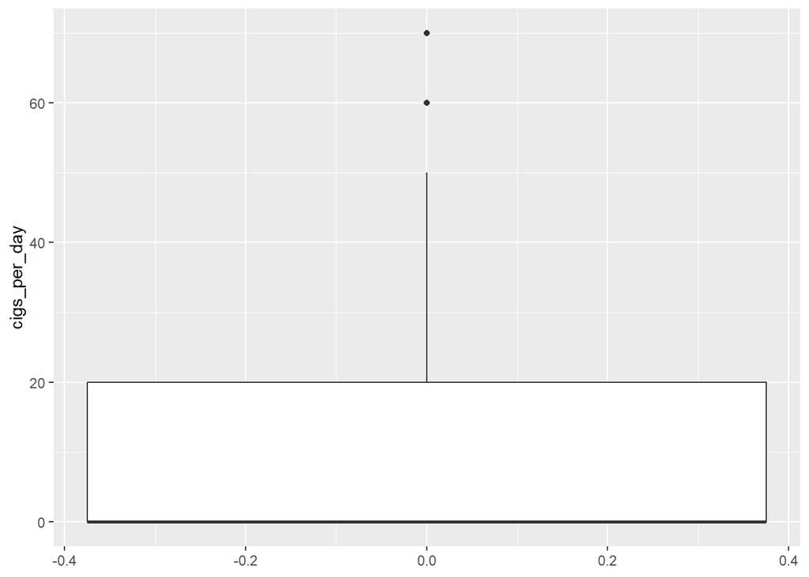

```
 [1] 60 60 60 60 60 60 60 60 60 60 60 70
```

##### Since there are outliers indicated, those are removed from the dataset.

**6. For cholesterol level**

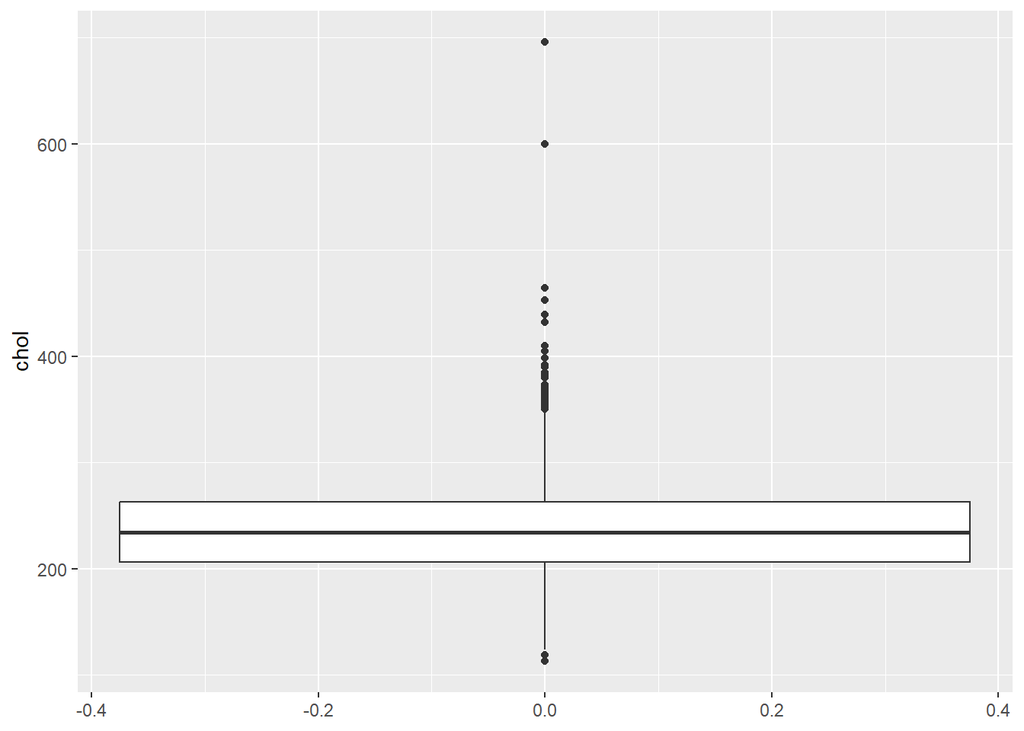

```
 [1] 391 366 364 361 382 372 350 432 352 380 368 600 354 367 355 410 370 390 464
[20] 358 385 398 352 355 390 350 351 382 696 392 359 453 371 353 405 352 439 352
[39] 358 119 410 360 410 113 373 350 363
```

- Ditermining the values of extreme outliers

```
[1] 696 600
```

##### Since there are extreme outliers compared to other outliers and when considering the general case also there is a rare chance of having such values.Therefore it is remved from the data set.

##### **Summary of the data set**

```
'data.frame':   3900 obs. of  8 variables:
 $ age           : int  54 45 58 42 42 57 43 42 37 49 ...
 $ sex           : chr  "male" "male" "male" "male" ...
 $ current_smoker: chr  "yes" "yes" "yes" "yes" ...
 $ heart_rate    : int  95 64 81 90 62 62 75 66 65 93 ...
 $ cigs_per_day  : int  NA NA NA NA NA NA NA NA NA NA ...
 $ chol          : int  219 248 235 225 226 223 222 196 188 256 ...
 $ systolic_bp   : num  110 121 128 122 119 ...
 $ diastolic_bp  : num  72 72 76 80 80 72.5 69 73 77 81.5 ...
```

```
      age            sex            current_smoker       heart_rate
 Min.   :32.00   Length:3900        Length:3900        Min.   : 44.00
 1st Qu.:42.00   Class :character   Class :character   1st Qu.: 68.00
 Median :49.00   Mode  :character   Mode  :character   Median : 75.00
 Mean   :49.54                                         Mean   : 75.69
 3rd Qu.:56.00                                         3rd Qu.: 82.00
 Max.   :70.00                                         Max.   :143.00

  cigs_per_day         chol        systolic_bp     diastolic_bp
 Min.   : 0.000   Min.   :113.0   Min.   : 83.5   Min.   : 48.00
 1st Qu.: 0.000   1st Qu.:206.0   1st Qu.:117.0   1st Qu.: 75.00
 Median : 0.000   Median :234.0   Median :128.0   Median : 82.00
 Mean   : 9.009   Mean   :236.4   Mean   :132.4   Mean   : 82.99
 3rd Qu.:20.000   3rd Qu.:263.0   3rd Qu.:144.0   3rd Qu.: 90.00
 Max.   :50.000   Max.   :464.0   Max.   :248.0   Max.   :142.50
 NA's   :26       NA's   :9       NA's   :1
```

### **Composition of the sample**

**1. For gender**

```
  Gender Count Percentage
1 female  2081      53.36
2   male  1819      46.64
```

In this sample number of females are higher than number of males.

**2. For current_smoker**

```
  Smoking_status Count Percentage
1             no  1968      50.46
2            yes  1932      49.54
```

In this sample the number of people who do not smoke are higher than the number of people who smoke but as percentage it is approximately same.

**3. Smoking condition by gender**

```
  Gender Smoking status Count Percentage
1 female             no  1254      32.15
2   male             no   714      18.31
3 female            yes   827      21.21
4   male            yes  1105      28.33
```

In this sample the number of non smoking females are higher than the number of non smoking males and the number of smoking females are lower than the number of smoking males. Majority holds the number of non smoking females in the sample.

### **Data Description**

**1. For age**

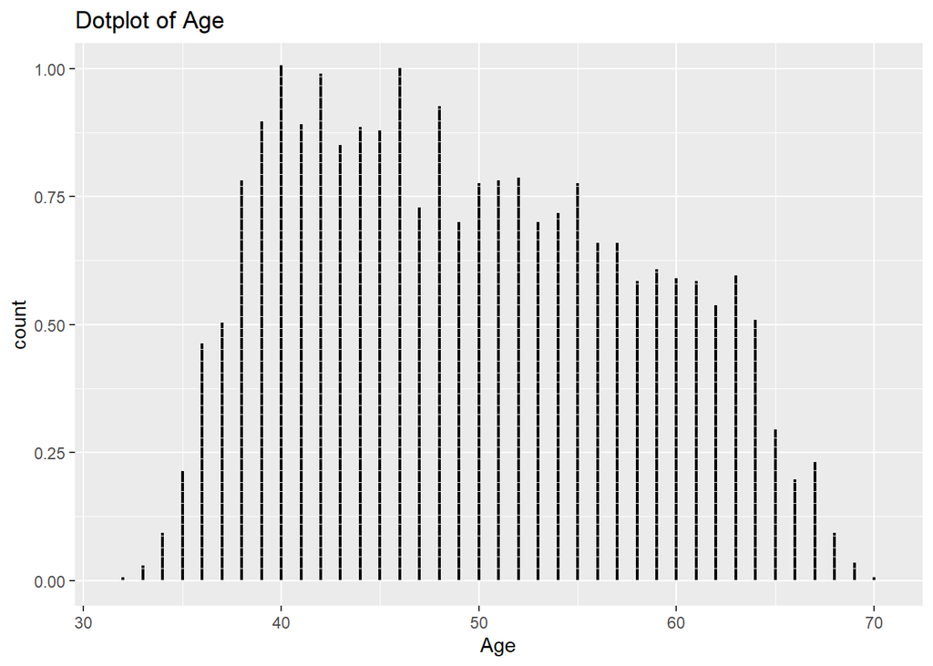

```
   Min. 1st Qu.  Median    Mean 3rd Qu.    Max.
  32.00   42.00   49.00   49.54   56.00   70.00
```

According to the dot plot of age, it is shown that data are symmetrically distributed and it is proved by the summary statistics because mean and median values are approximately equal.

**2. For heart rate**

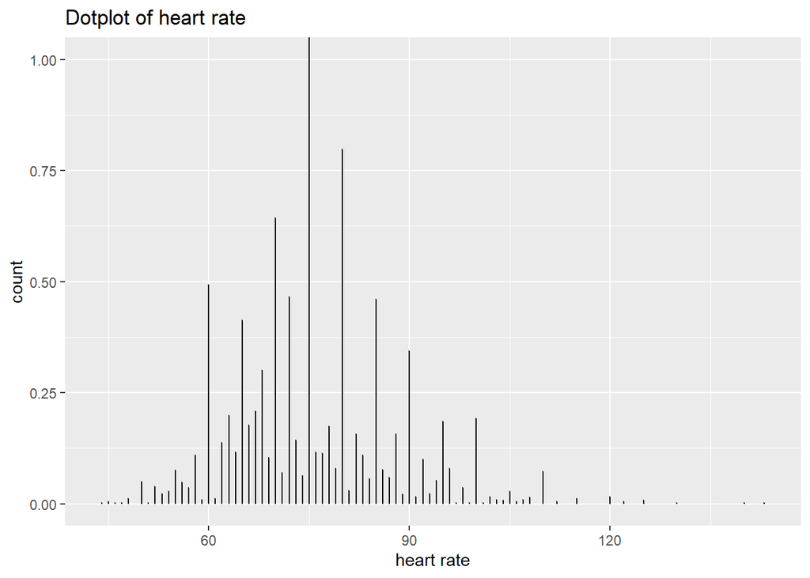

```
   Min. 1st Qu.  Median    Mean 3rd Qu.    Max.
  44.00   68.00   75.00   75.69   82.00  143.00
```

According to the dot plot of heart rate, it is shown that data are symmetrically distributed and it is proved by the summary statistics because mean and median values are approximately equal.

**3. For number of cigarettes per day**

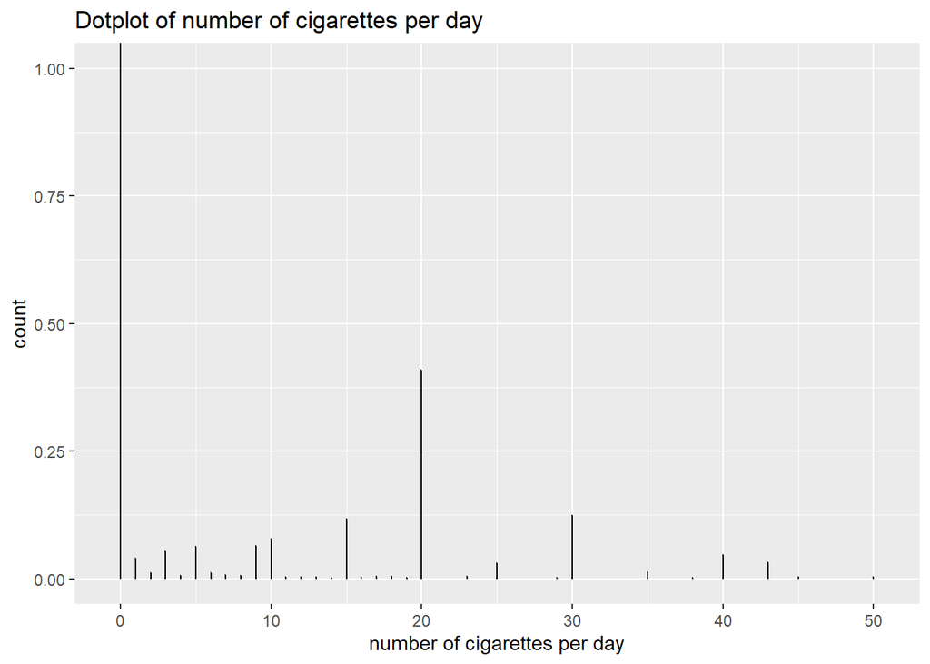

```
   Min. 1st Qu.  Median    Mean 3rd Qu.    Max.    NA's
  0.000   0.000   0.000   9.009  20.000  50.000      26
```

According to the dot plot of number of cigarettes, it is shown that data are asymmetrically distributed and it is positively skewed distribution. It is proved by the summary statistics because mean value is higher than median value.

**4. For cholesterol level**

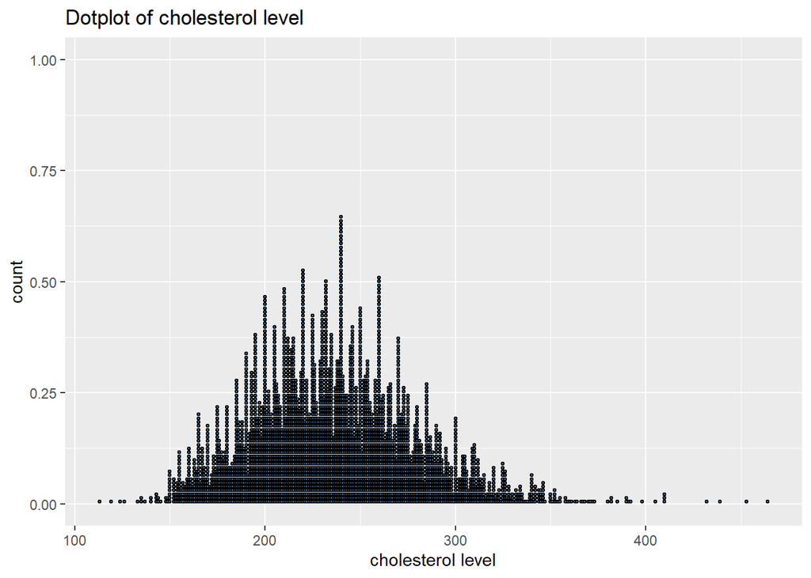

```
   Min. 1st Qu.  Median    Mean 3rd Qu.    Max.    NA's
  113.0   206.0   234.0   236.4   263.0   464.0       9
```

According to the dot plot of cholesterol level, it is shown that data are symmetrically distributed with mean 236 and it is proved by the summary statistics because mean and median values are approximately equal.

**5. For systolic blood pressure**

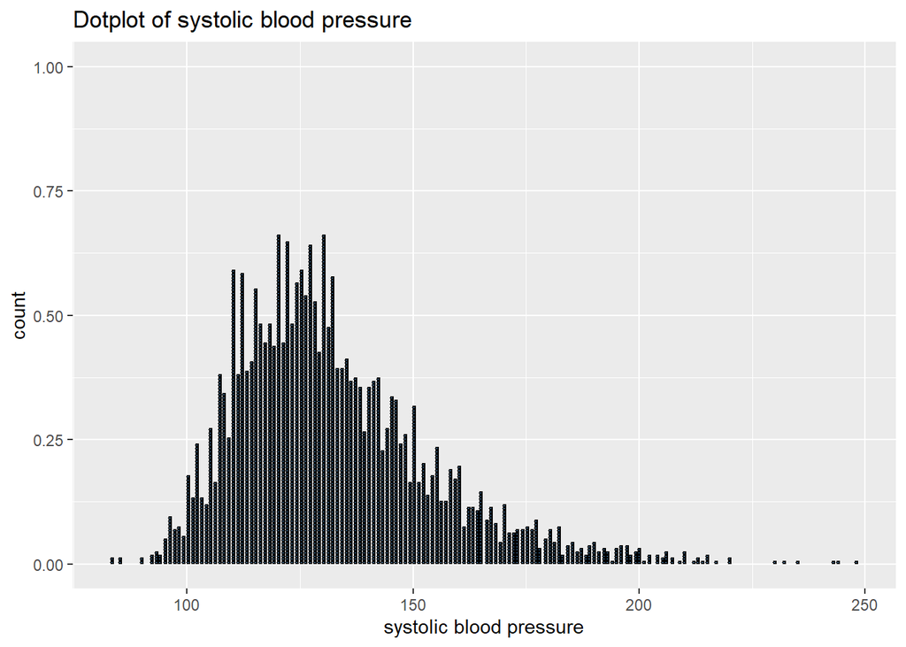

```
   Min. 1st Qu.  Median    Mean 3rd Qu.    Max.    NA's
   83.5   117.0   128.0   132.4   144.0   248.0       1
```

According to the dot plot of systolic blood pressure, it is shown that data are asymmetrically distributed with median 128 and it is positively skewed distribution. It is proved by the summary statistics because mean value is higher than median value.

**6. For diastolic blood pressure**

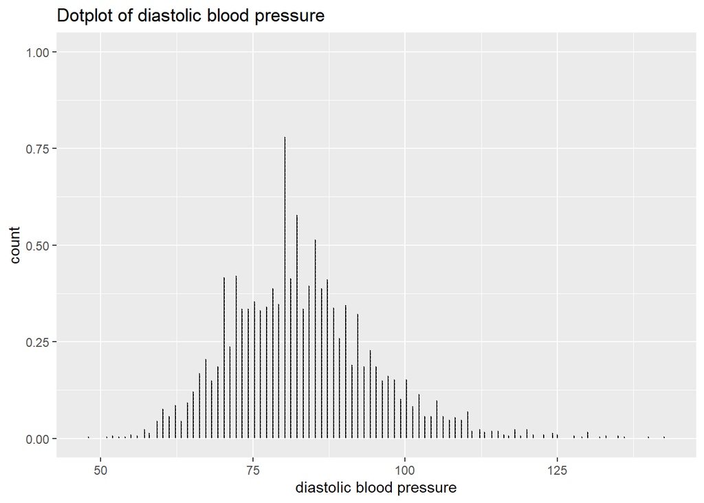

```
   Min. 1st Qu.  Median    Mean 3rd Qu.    Max.
  48.00   75.00   82.00   82.99   90.00  142.50
```

According to the dot plot of diastolic blood pressure, it is shown that data are symmetrically distributed with mean 83 approximately and it is proved by the summary statistics because mean and median values are approximately equal.

**7. For cholesterol level in terms of smoking condition**

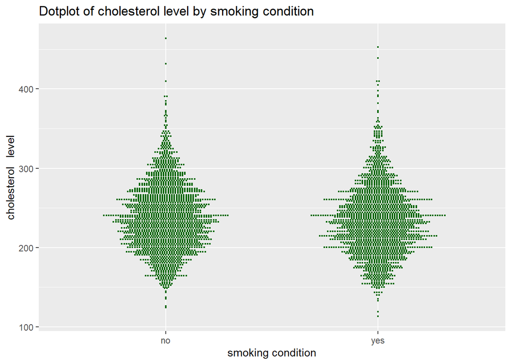

- **Summary statistics of cholesterol level in terms of smoking condition (yes and no)**

```
$no
   Min. 1st Qu.  Median    Mean 3rd Qu.    Max.    NA's
  124.0   208.0   235.0   238.5   266.0   464.0       4

$yes
   Min. 1st Qu.  Median    Mean 3rd Qu.    Max.    NA's
  113.0   204.0   232.0   234.3   260.0   453.0       5
```

**8. For heart rates in terms of smoking condition**

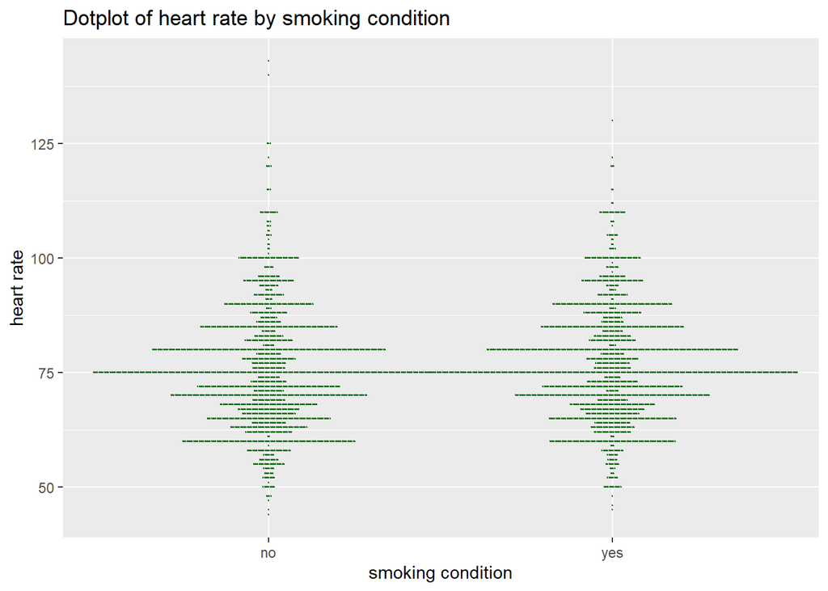

- **Summary statistics of heart rate in terms of smoking condition (yes and no)**

```
$no
   Min. 1st Qu.  Median    Mean 3rd Qu.    Max.
  44.00   67.00   75.00   75.01   81.00  143.00

$yes
   Min. 1st Qu.  Median    Mean 3rd Qu.    Max.
  45.00   68.00   75.00   76.38   84.00  130.00
```

According to the dot plot it is shown that the maximum heart rate indicated at 75, regardless the smoking condition. The distributions of heart rate for both smoking conditions are symmetric and it is proved by the summary statistics because the mean and median values are approximately equal for each smoking condition.

**9. For systolic blood pressure in terms of smoking condition**

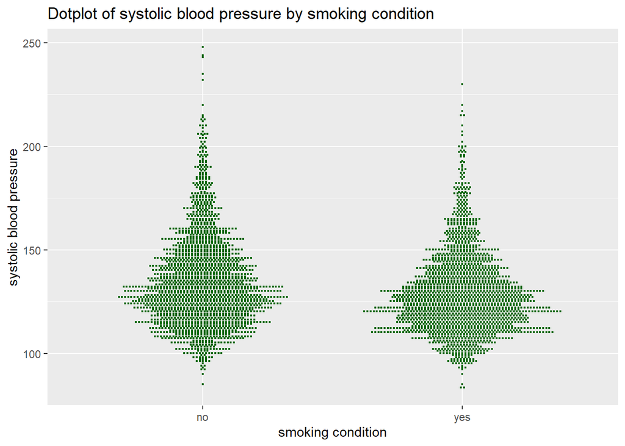

- **Summary statistics of systolic blood pressure in terms of smoking condition (yes and no)**

```
$no
   Min. 1st Qu.  Median    Mean 3rd Qu.    Max.    NA's
   85.5   119.0   131.0   135.3   147.0   248.0       1

$yes
   Min. 1st Qu.  Median    Mean 3rd Qu.    Max.
   83.5   115.0   126.0   129.4   139.6   230.0
```

**10. For diastolic blood pressure in terms of smoking condition**

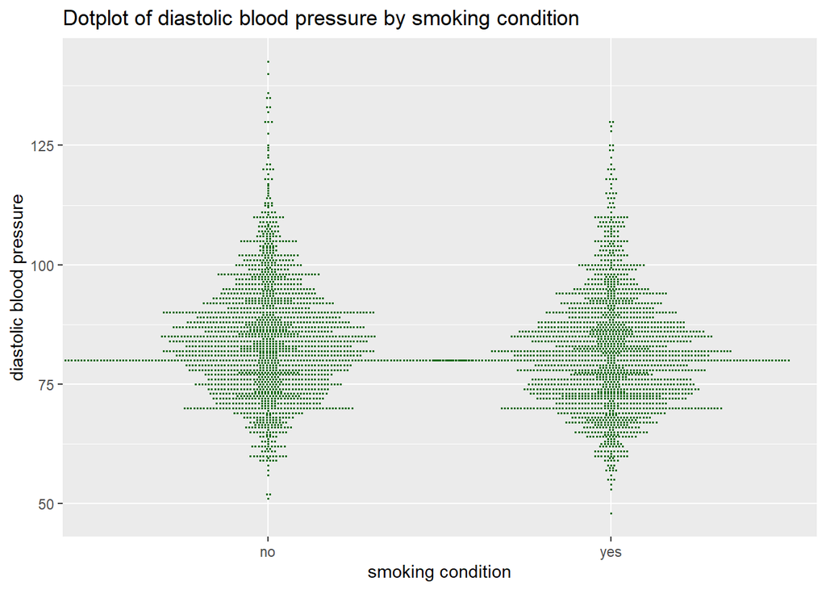

- **Summary statistics of diastolic blood pressure in terms of smoking condition (yes and no)**

```
$no
   Min. 1st Qu.  Median    Mean 3rd Qu.    Max.
  51.00   76.50   83.00   84.31   91.00  142.50

$yes
   Min. 1st Qu.  Median    Mean 3rd Qu.    Max.
  48.00   73.00   81.00   81.64   88.00  130.00
```

According to the dot plot it is shown that diastolic blood pressure of majority is varied the range between approximately 70 to 100 regardless the smoking condition. The distributions of cholesterol level for both smoking conditions are symmetric and it is proved by the summary statistics because the mean and median values are approximately equal for each smoking condition.

**11. For heart rate in terms of gender**

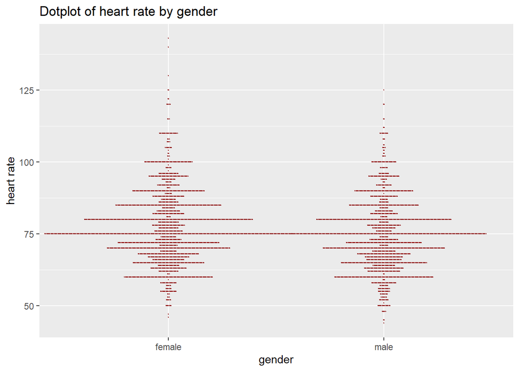

- **Summary statistics of heart rate in terms of gender (male and female)**

```
$female
   Min. 1st Qu.  Median    Mean 3rd Qu.    Max.
  46.00   69.00   75.00   76.94   85.00  143.00

$male
   Min. 1st Qu.  Median    Mean 3rd Qu.    Max.
  44.00   66.00   75.00   74.26   80.00  125.00
```

According to the dot plot it is shown that heart rate of majority is varied the range between approximately 60 to 80 regardless the gender. The distributions of cholesterol level for both genders are symmetric and it is proved by the summary statistics because the mean and median values are approximately equal for both males and females.

**12. For cholesterol level in terms of gender**

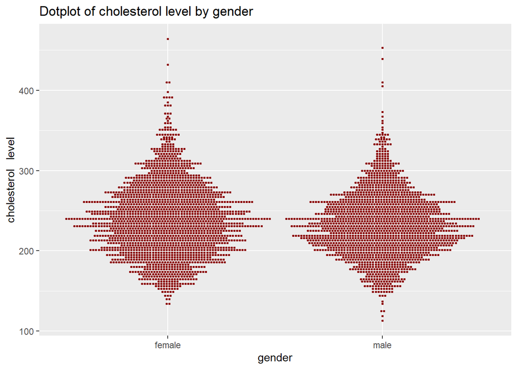

- **Summary statistics of cholesterol level in terms of gender (male and female)**

```
$female
   Min. 1st Qu.  Median    Mean 3rd Qu.    Max.    NA's
  135.0   206.0   237.0   239.5   269.0   464.0       1

$male
   Min. 1st Qu.  Median    Mean 3rd Qu.    Max.    NA's
  113.0   206.0   230.0   232.9   258.0   453.0       8
```

According to the dot plot it is shown that cholesterol level of majority is varied the range between approximately 200 to 300 regardless the gender. The distributions of cholesterol level for both genders are symmetric and it is proved by the summary statistics because the mean and median values are approximately equal for both males and females.

**13. For systolic blood pressure in terms of gender**

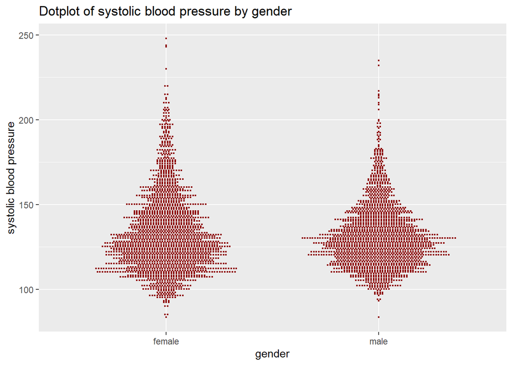

- **Summary statistics of systolic blood pressure in terms of gender (male and female)**

```
$female
   Min. 1st Qu.  Median    Mean 3rd Qu.    Max.    NA's
   83.5   116.0   128.0   133.2   146.0   248.0       1

$male
   Min. 1st Qu.  Median    Mean 3rd Qu.    Max.
   83.5   118.0   128.0   131.4   141.0   235.0
```

According to the dot plot it is shown that systolic blood pressure of majority is varied the range between approximately 100 to 150 regardless the gender. The distributions of systolic blood pressure for both genders are positively skewed and it is proved by the summary statistics because the mean value is higher than the median value for both males and females.

**14.For diastolic blood pressure in terms of gender**

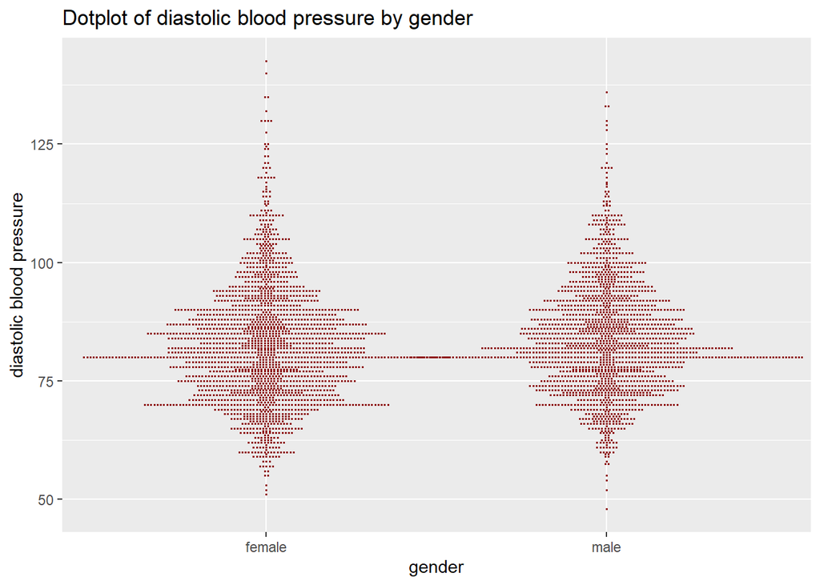

- **Summary statistics of diastolic blood pressure in terms of gender (male and female)**

```
$female
   Min. 1st Qu.  Median    Mean 3rd Qu.    Max.
  51.00   74.00   81.00   82.36   89.00  142.50

$male
   Min. 1st Qu.  Median    Mean 3rd Qu.    Max.
   48.0    76.0    82.0    83.7    90.0   136.0
```

**15. For number of consuming cigarettes per day in terms of gender**

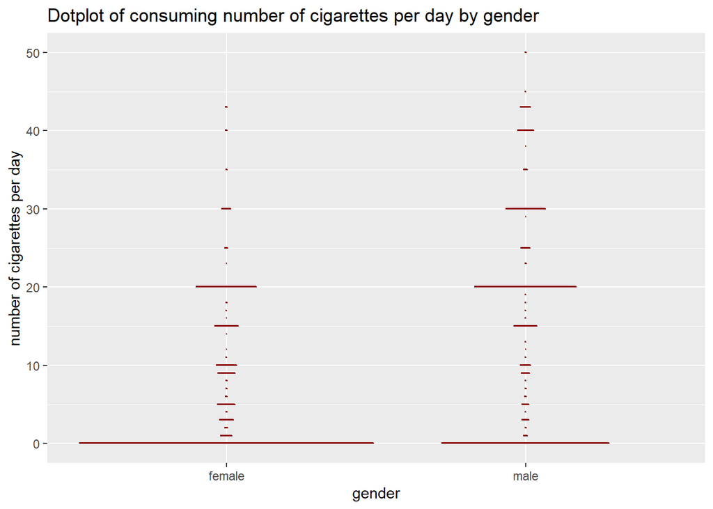

- **Summary statistics of number of consuming cigarettes per day in terms of gender (male and female)**

```
$female
   Min. 1st Qu.  Median    Mean 3rd Qu.    Max.
  0.000   0.000   0.000   5.528  10.000  43.000

$male
   Min. 1st Qu.  Median    Mean 3rd Qu.    Max.    NA's
   0.00    0.00   13.00   13.05   20.00   50.00      26
```

**16.For age vs number of consuming cigarettes per day according to gender**

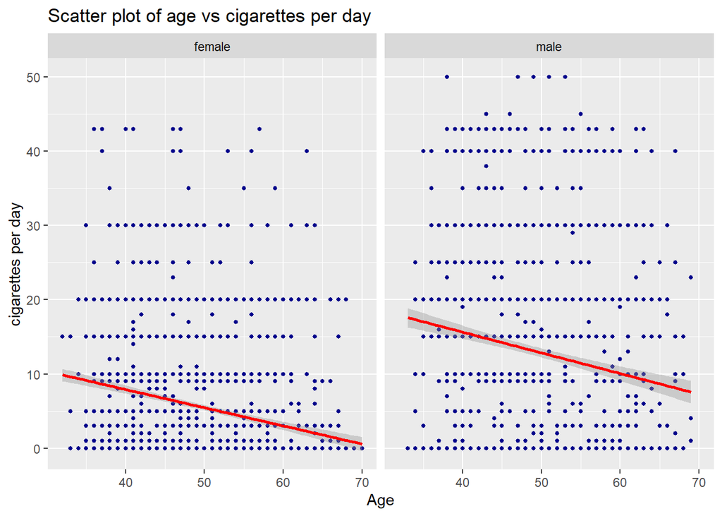

**17.For cholesterol level vs number of consuming cigarettes per day**

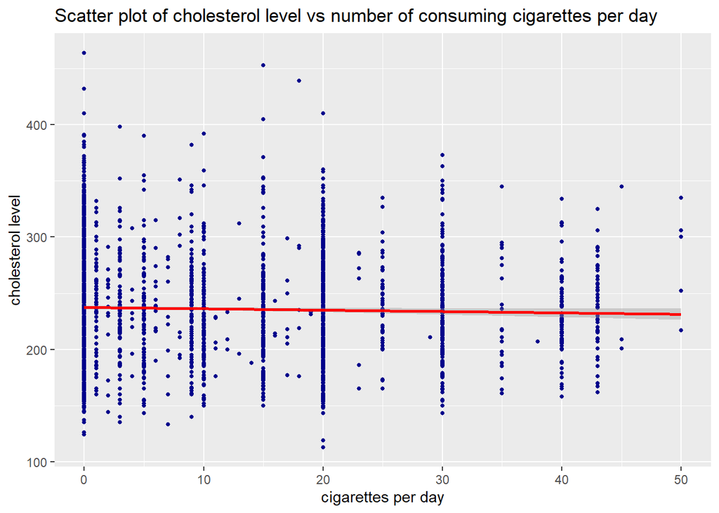

**18. For systolic blood pressure vs number of consuming cigarettes per day**

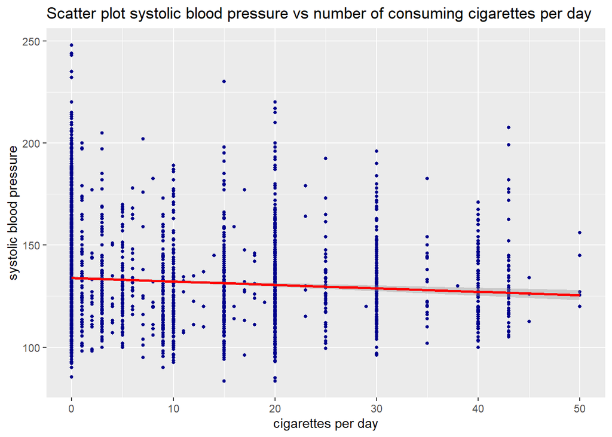

**19.. For diastolic blood pressure vs number of consuming cigarettes per day**

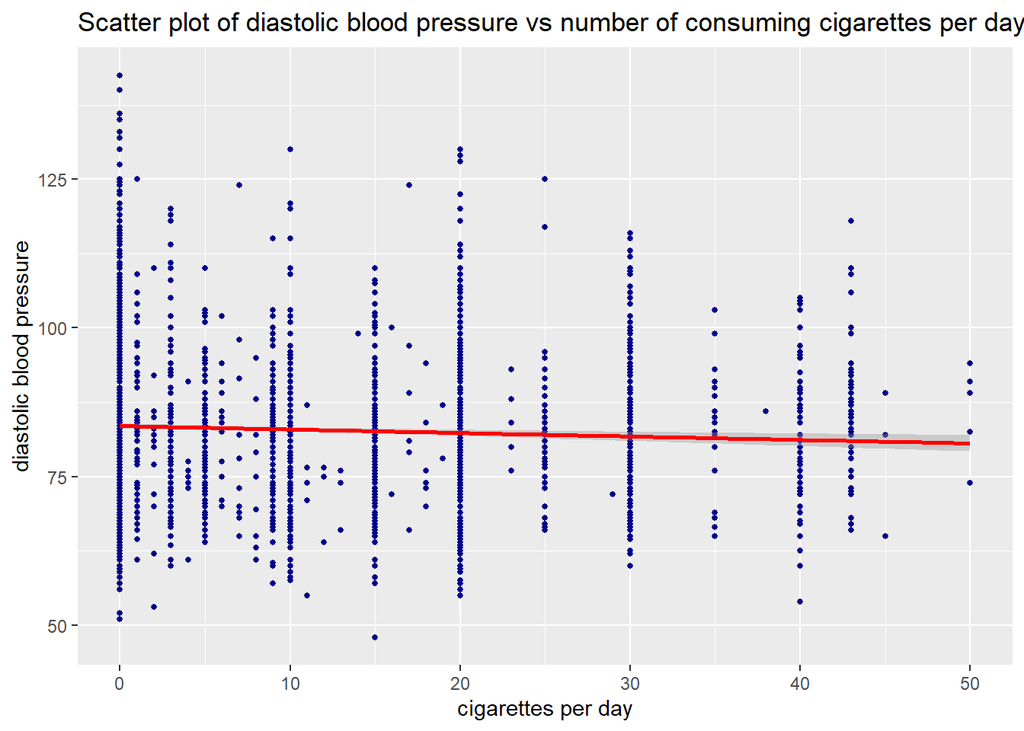

There are negative, weak relationships between age and number of consuming cigarettes per day among both males and females, cholesterol level and number of consuming cigarettes per day, systolic blood pressure and number of consuming cigarettes per day, diastolic blood pressure and number of consuming cigarettes per day.While there is a slight downward trend, the large spread of points indicates a weak association.

**20. For heart rate vs cholesterol level**

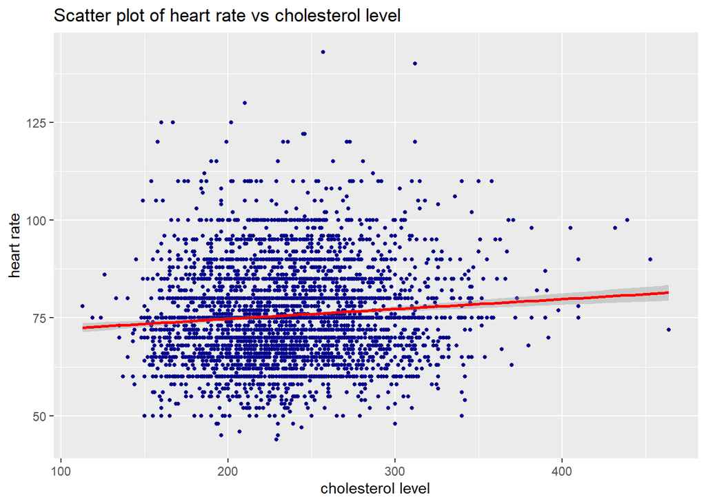

**21. For heart rate vs number of consuming cigarettes per day**

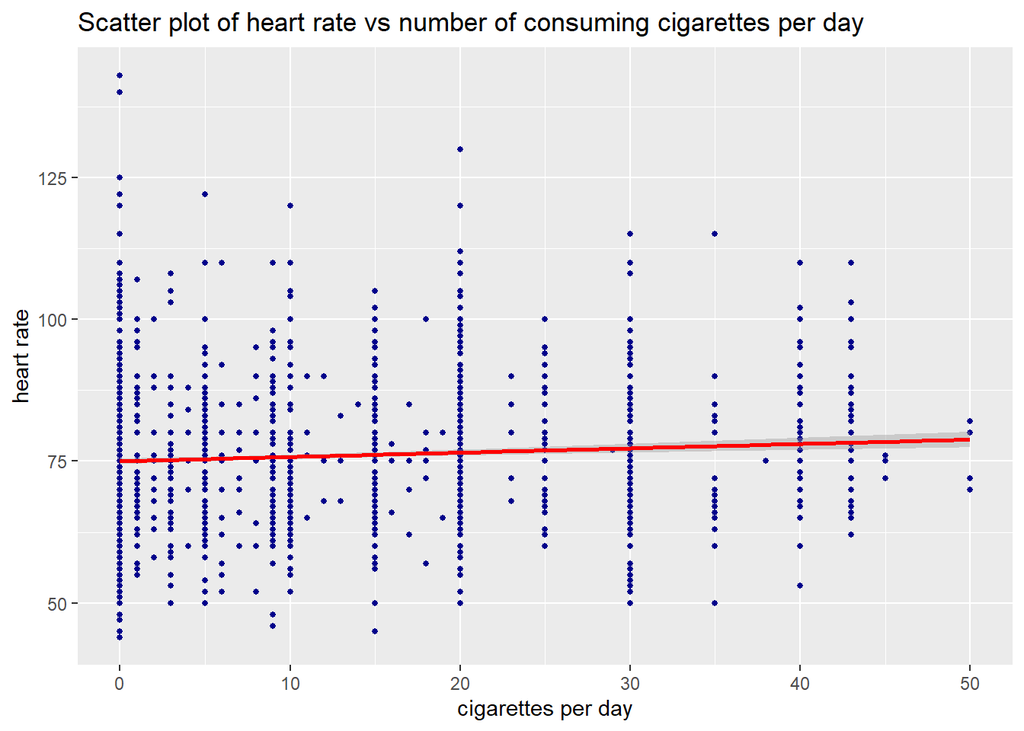

**22. For heart rate vs systolic blood pressure**

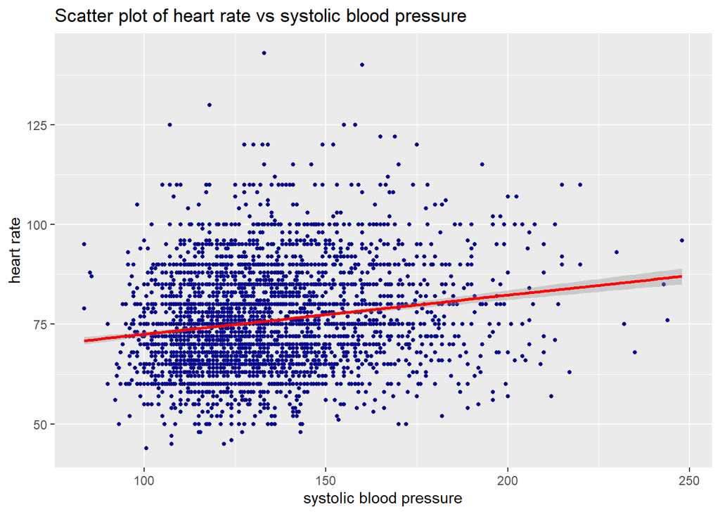

**23.For heart rate vs diastolic blood pressure**

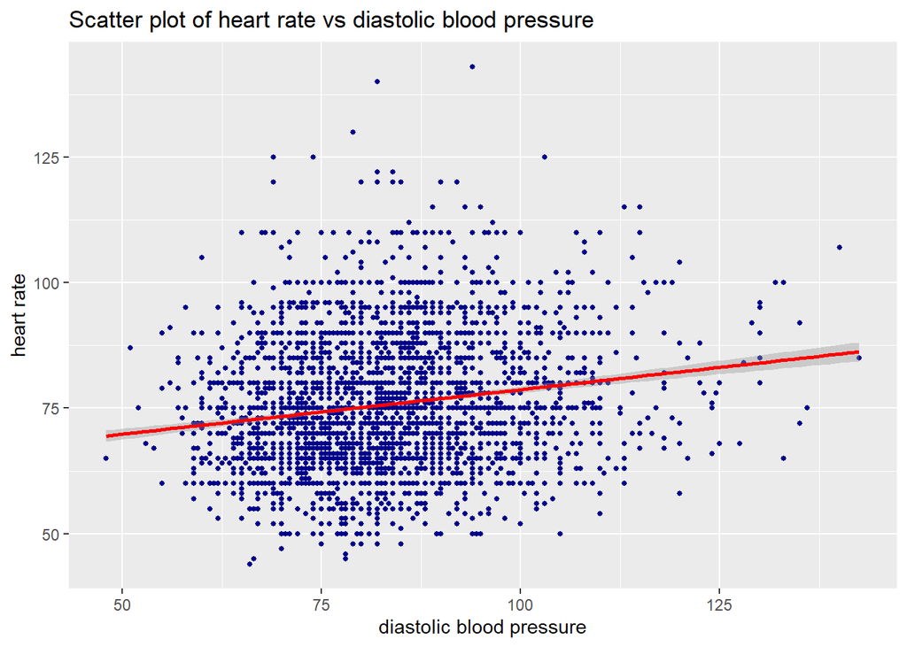

There are weak, positive relationships between heart rate vs cholesterol level, heart rate and number of consuming cigarettes per day, heart rate and systolic blood pressure, heart rate vs diastolic blood pressure.While there is a slight upward trend, the large spread of points indicates a weak association.

**24. Correlation between two quantitative variables**

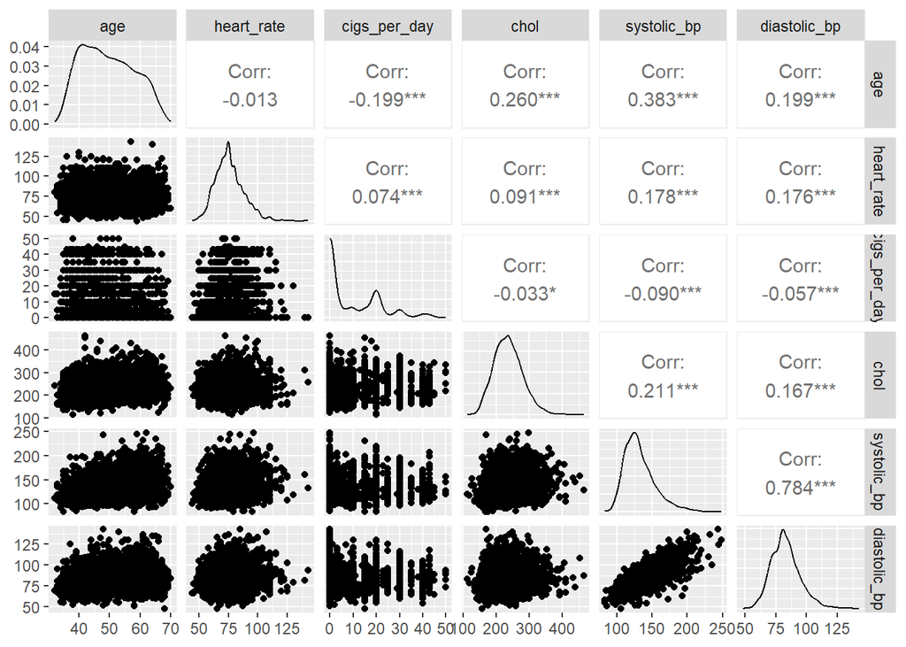

Above chart shows the correlation between two quantitative variables which discussed in this study. Both positive and negative relationships are occurred but all of them are not strong relationships except the relationship between systolic blood pressure and diastolic blood pressure because it as a strong, positive relationship.  
There are weak, negative relationships between age and heart rate, age and cigarettes consumed per day, cholesterol level and and cigarettes consumed per day, systolic blood pressure and cigarettes consumed per day, diastolic blood pressure and cigarettes consumed per day.  
There are weak, positive relationships between cholesterol level and age, systolic blood pressure and age, diastolic blood pressure and age, cigarettes consumed per day and heart rate, cholesterol level and heart rate, systolic blood pressure and heart rate, diastolic blood pressure and heart rate, systolic blood pressure and cholesterol level, diastolic blood pressure and cholesterol level.

### **Discussion**

1. In the original data set both systolic and diastolic blood pressures were indicated together as blood pressure. But for the convenience of analysis it was separated as two quantitative variables.
2. All the outliers indicated by the box plot are not removed because some of can be happened in real scenarios. But some outliers are eliminated because they indicate as extreme outliers and show less number of outliers separately.
3. Removed outliers are taken as null values.
4. Missing values of categorical variables are also assigned as null values.
5. Since the data points are not scattered perfectly, a smooth line is used to detect the trend.
6. The data may contain variability due to measurement error, unmeasured confounding variables, or differences in participant health status.